# Wordle Data Analysis

Brenda Luis

2025-11-09

# Introduction

Wordle is a popular online word puzzle where players guess a five letter word within six attempts. Each guess provides feedback: letters in the correct position are highlighted in green, letters in the word but in the wrong position appear yellow, and letters not in the word are gray. Beyond being an engaging game, Wordle presents a rich dataset for analysis. Words have unique characteristics, such as vowel-consonant balance, repeated letters, rare letters, palindromes, Scrabble scores, and frequency of usage.

This analysis explores these patterns across 1600+ Wordle words to uncover trends in word selection, letter placement, and other structural features. By examining the relationships between word properties, frequency, and temporal trends, this project aims to provide insights into the hidden patterns that shape the daily puzzle.

# Questions to Answer

# Data Preparation

[output not shown]

[output cut: 1575 more lines]

## Letter Counts

letter counts overall show trends on most used letters

note: my own scores. how many tries did it take me

[output not shown]

[output cut: 9621 more lines]

```
## # A tibble: 4 × 2
##   Letter Counts
##   <chr>   <int>
## 1 E         873
## 2 A         705
## 3 R         630
## 4 O         545
```

```
## # A tibble: 4 × 2
##   Letter Counts
##   <chr>   <int>
## 1 X          31
## 2 Z          28
## 3 Q          22
## 4 J          19
```

```
## # A tibble: 26 × 2
##    Letter Counts
##    <chr>   <int>
##  1 E         873
##  2 A         705
##  3 R         630
##  4 O         545
##  5 T         537
##  6 L         496
##  7 I         453
##  8 S         437
##  9 N         405
## 10 C         321
## # ℹ 16 more rows
```

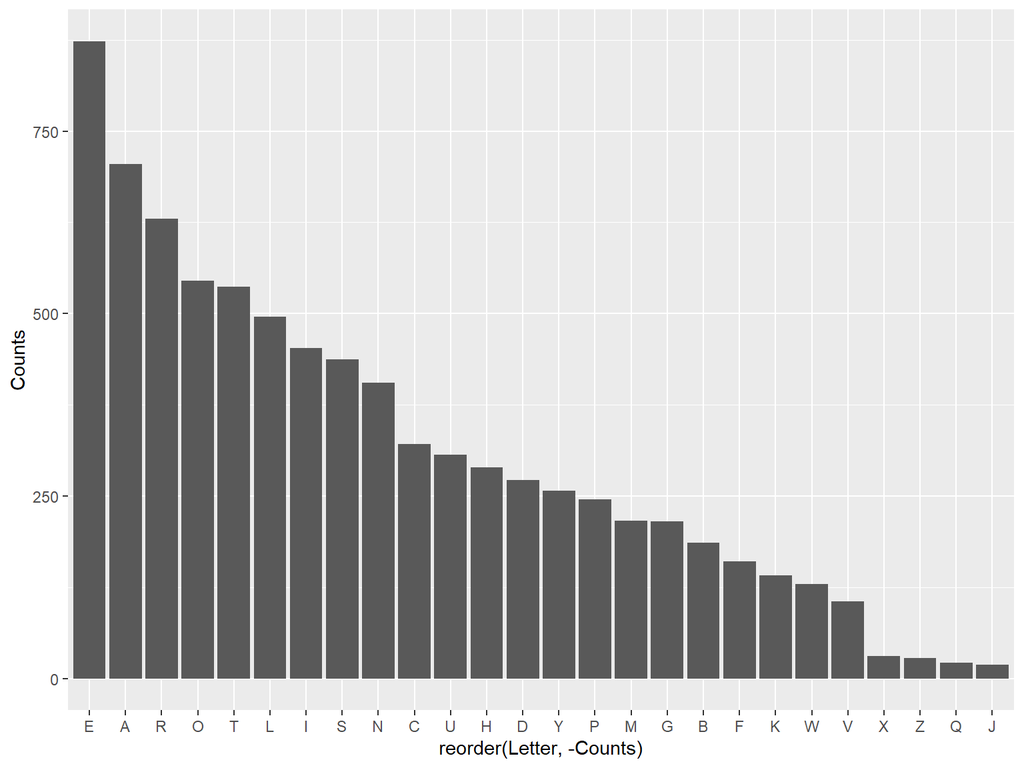

## Letter Counts by position

letter counts by positions show trends on most used letters by position

The heatmap shows how frequently each letter appears in each position of Wordle answers. Darker shades indicate more common letters. By visualizing letter frequency across positions we can identify common structural patterns in five letter words like certain consonants often starting words.

S appears very often in P1 (starting position) Y is very common in P5

```
## # A tibble: 125 × 3
## # Groups:   Position [5]
##    Position Letter Counts
##    <chr>    <chr>   <int>
##  1 P1       S         237
##  2 P1       C         133
##  3 P1       B         121
##  4 P1       T         110
##  5 P1       A         103
##  6 P1       P          95
##  7 P1       F          93
##  8 P1       G          85
##  9 P1       M          79
## 10 P1       D          70
## # ℹ 115 more rows
```

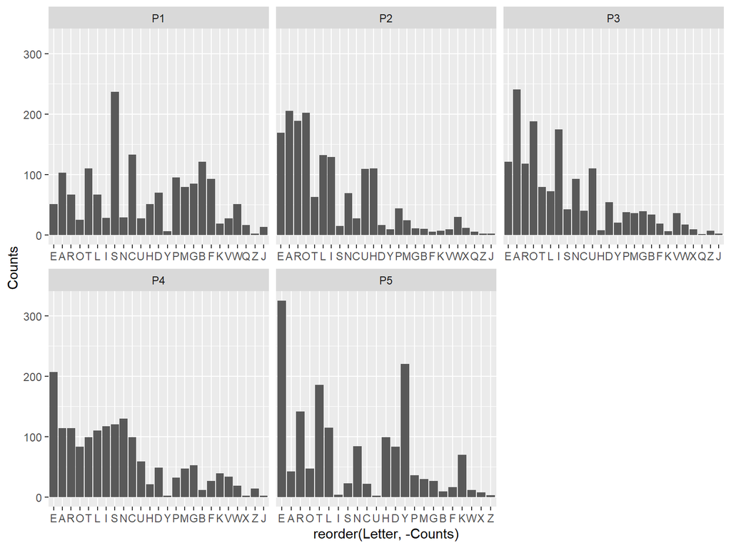

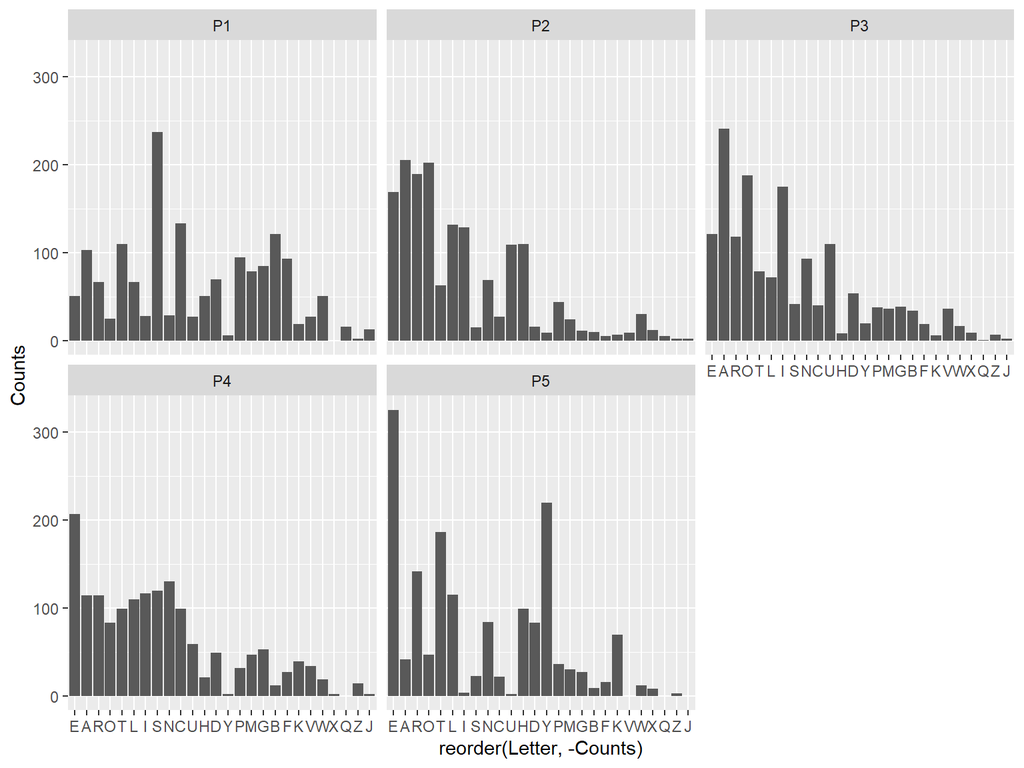

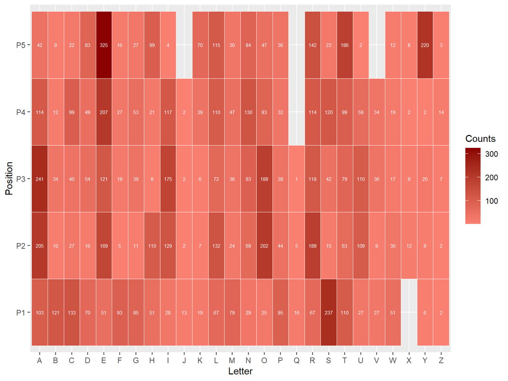

## Data Analysis

```
## # A tibble: 354 × 2
##    Bigram Counts
##    <chr>   <int>
##  1 ER        134
##  2 IN         93
##  3 ST         91
##  4 RA         80
##  5 AR         79
##  6 RO         78
##  7 AL         75
##  8 CH         75
##  9 RE         75
## 10 EA         73
## # ℹ 344 more rows
```

## MOST COMMON BIGRAMS

position not taken into account here

what does this graph tell us? the Most Common Bigrams plot shows which two letter combos appear most frequently across all Wordle answers regardless of where they occur in the word. This gives insight into the most common letter pairings in English five letter words which can be useful for players choosing strong starting guesses.

```
## # A tibble: 25 × 2
##    Bigram Counts
##    <chr>   <int>
##  1 ER        134
##  2 IN         93
##  3 ST         91
##  4 RA         80
##  5 AR         79
##  6 RO         78
##  7 AL         75
##  8 CH         75
##  9 RE         75
## 10 EA         73
## # ℹ 15 more rows
```

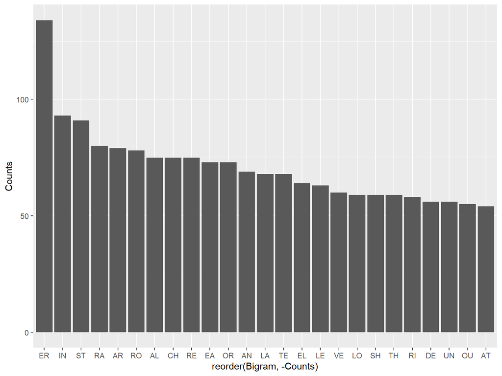

## Most common bigrams by position?

```
## # A tibble: 891 × 3
## # Groups:   Position [4]
##    Position Bigram Counts
##    <chr>    <chr>   <int>
##  1 B1       ST         52
##  2 B1       SH         34
##  3 B1       SP         33
##  4 B1       BR         30
##  5 B1       CH         30
##  6 B1       GR         30
##  7 B1       CR         29
##  8 B1       FL         27
##  9 B1       MA         27
## 10 B1       TR         26
## # ℹ 881 more rows
```

```
## # A tibble: 41 × 3
## # Groups:   Position [4]
##    Position Bigram Counts
##    <chr>    <chr>   <int>
##  1 B1       ST         52
##  2 B1       SH         34
##  3 B1       SP         33
##  4 B1       BR         30
##  5 B1       CH         30
##  6 B1       GR         30
##  7 B1       CR         29
##  8 B1       FL         27
##  9 B1       MA         27
## 10 B1       TR         26
## # ℹ 31 more rows
```

[figure not shown]

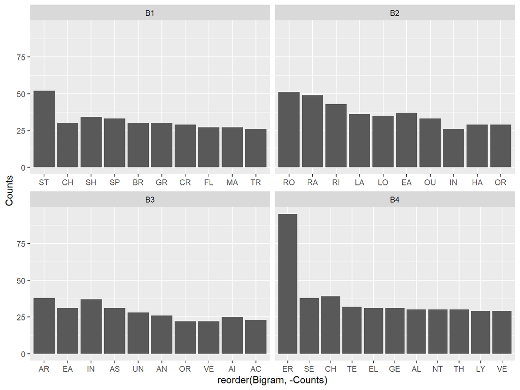